# 大阪府 (議員定数：19 → 19)

アルゴリズムによる衆議院小選挙区の区割り改定案

ALARM Japan プロジェクトチーム  
June 30, 2022

**大阪府**

人口： 8,629,004 人（2020年）

|  | 現行 | 新たな区割り | アルゴリズムの提案 |
| --- | --- | --- | --- |
| **1票の格差** |  |  |  |
| 県内較差 | 1.530 | 1.453 | 1.437 |
| 改善率 | - | 14.5% | 17.6% |
| **選挙区の状況** |  |  |  |
| 選挙区数 | 19 | 19 | 19 |
| 市区町村の分割 | 0 | 0 | 0 |
| 郡の分割 | 0 | 0 | 0 |
| 広域連携地域の分割 | 0 | 0 | 0 |

# 現行の区割り

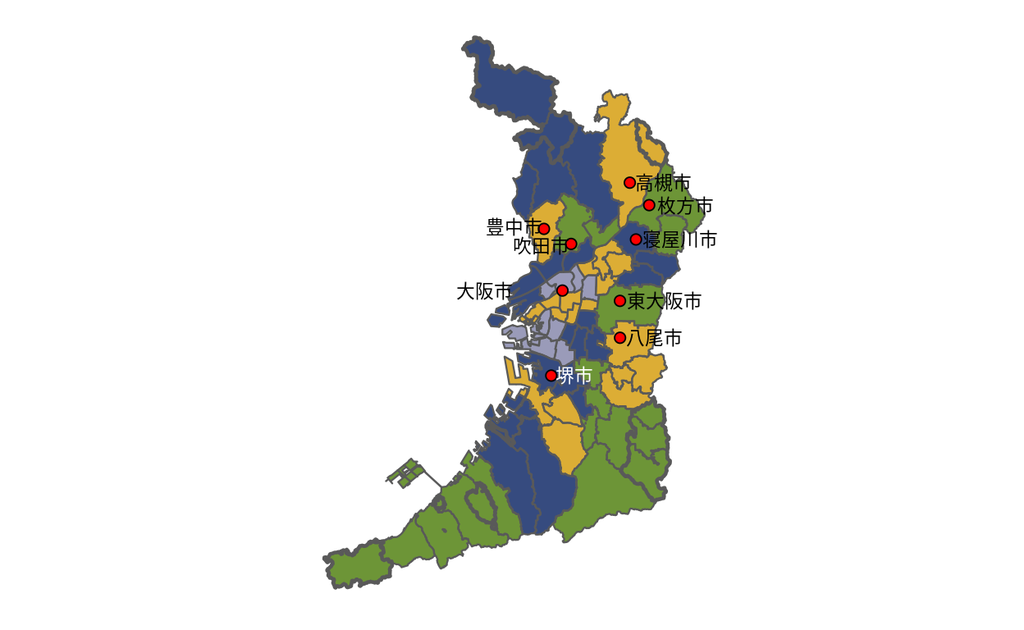

# アルゴリズムの提案

アルゴリズムが提案した5,000案のうち、一票の格差が最小のもの

一票の格差 : 1.437

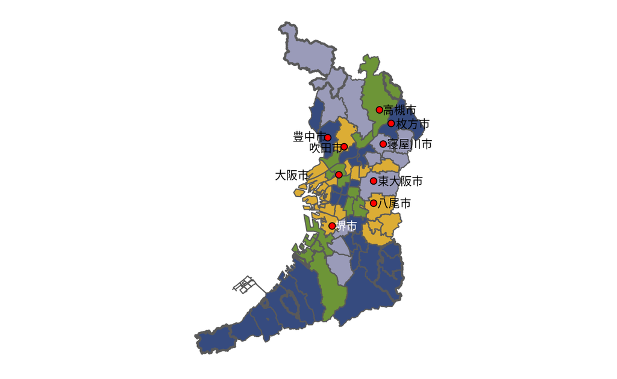

# 共起分析

- 有効な案のうち一票の格差が下位10％の案を抽出
- 隣接する地域と同じ選挙区に属する傾向が強い地域同士の集まりをk = 19 設定
- 読み取り方  
  地図上の地域の色が
  - 同じ → 同じ選挙区に属する傾向が強い
  - 同じ かつ 濃い → 隣接する地域と同じ選挙区に属する傾向が強い

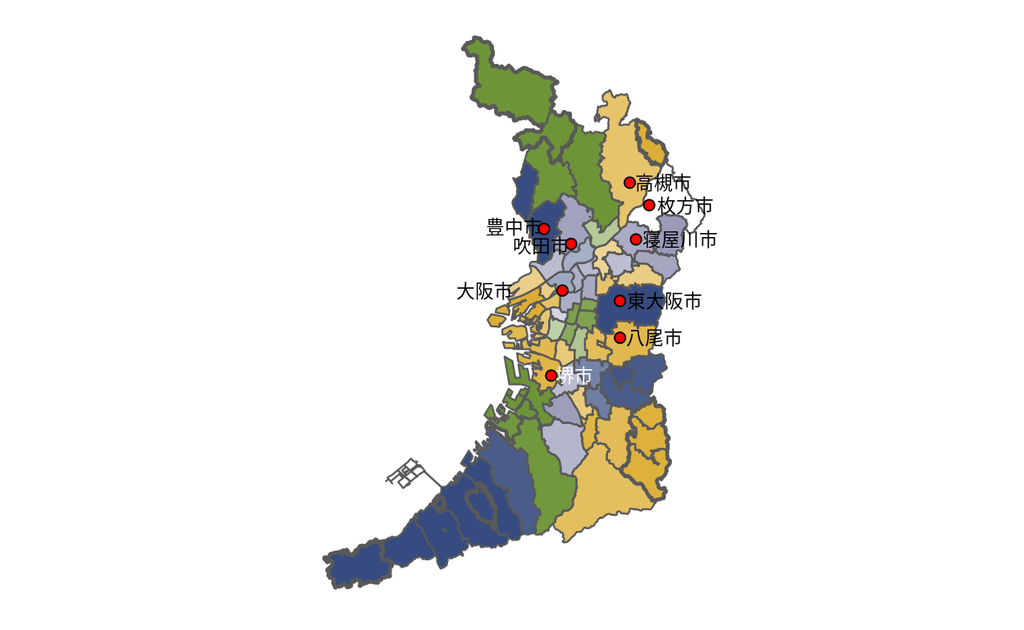

# アルゴリズム設定

- 各選挙区の人口 : (県内の日本人人口 / 選挙区数) ±25%
- 市区町村を基本の単位として扱う
  - ただし、現状の区割りにおいて分割されている市区町村については、シミュレーションにおいても分割を許容し、国勢調査における小地域を基本の単位として扱う
  - 現状の区割りにおいて分割されている市区町村がないため、シミュレーションにおいても市区町村分割を許容しない
- 市区町村の分割数の制限 (`add_constr_splits`)と、市区町村の複数選挙区への分割の制限(`add_constr_multisplits`) をそれぞれを設定
- 郡の分割は、現行の区割りにて分割されている場合のみ許容
- 離島は、航路で結ばれている本土の市区町村と同一の選挙区にする
- 逐次モンテカルロ法(SMC)による4つの独立したシミュレーションにより、区割り改定案を40,000作成
- 以下の案を棄却し有効な案を選定
  - 市区町村が3つ以上の選挙区に分割される案
  - 現状の区割りにおいて分割されていない郡・市区町村が分割される案
- 有効な案の中から5,000の案を無作為に抽出

### 府特有の設定

- 人口のデータが0または不明の、関西国際空港(泉佐野市泉州空港北、田尻町泉州空港中、泉南市泉州空港南)は、シェイプファイルから除外した。
- 以下の地域は隣接しているものとして扱った。
  - 此花区北港白津と此花区の大部分の地域
  - 岸和田市岸之浦町と岸和田市の大部分の地域
  - 高石市高砂と高石市の大部分の地域
- 以下の地域は飛び地であるが、現行の区割りでは飛び地として扱われていないため、本プロジェクトでも飛び地として扱わない。
  - 豊中市石橋麻田町
  - 茨木市小坪井
  - 寝屋川市打上元町
  - 堺市東区丈六
  - 羽曳野市埴生野

# データとプログラム

- [**Dataverse** : シュミレーションデータ](https://doi.org/10.7910/DVN/Z9UKSH)
- [**GitHub** : プログラム・コード](https://github.com/alarm-redist/japan)